# IODS course project

Nathalie Ylenia Triches

# Introduction to Open Data Science - Course Project

# 1. About the project

*This is a R Markdown file used for the “Introduction to Open Data Science” course at the University of Helsinki in 2023. The following lines are used to exercise the R Markdown syntax.*

### not-so-random thoughts

- I am feeling quite tired at the moment, it’s Friday afternoon.
- In this course, I expect to learn a few things:
  - using tidyverse as a modern tool for R (rather than R base)
  - learn how to use GitHub since I have no experience with it
  - learn how to version-control RStudio projects
- I saw the course in SISU and in my PhD programme (ATM-DP) [^1].

Here is a link to my GitHub repository: https://github.com/ntriches/IODS-project

```r
# This is a so-called "R chunk" where you can write R code.
# I don't have a code yet so I will leave this the way it is.

date()
```

```
## [1] "Sun Nov 26 08:58:10 2023"
```

*Here below, I try to describe the work and results of the first week a. k. a. “warm up phase” of the IODS 2023 project.*

#### Reflection on “Start me up!”

- I had to re-do the whole project twice to be able to get my course diary live - no idea what the mistake was
- I did not manage to commit-push with the Personal Access Token (PAT). The error was: *remote: Permission to ntriches/IODS-project.git denied to ntriches. fatal: unable to access ‘https://github.com/ntriches/IODS-project.git/’: The requested URL returned error: 403*
- I tried to solve it according to [a stackoverflow answer](https://stackoverflow.com/questions/52533318/how-to-solve-the-requested-url-returned-error-403-in-git-repository) but that didn’t work neither
- In the end, I uploaded an [SSH key](https://docs.github.com/en/authentication/connecting-to-github-with-ssh/generating-a-new-ssh-key-and-adding-it-to-the-ssh-agent). With this, I can commit - push using the terminal, which works very well.

#### Reflection on learning experiences “R for Health Data Science”

… from “R for Health Data Science” chapter 1-4 and exercise set 1.

- “R for Health Data Science” is a really nice book! I wish I had known it before
- If I didn’t know anything about R / RStudio, I think I’d be quite overwhelmed, simply because there is so much information
- My favourite topics were “2.11 joining multiple datasets” and “3.5 summarise() vs mutate()” and “4.9 multiple geoms, multiple aes()”

# 2. Regression and model validation

*This file describes the work and results of the second week a. k. a. “Regression and model validation” of the IDOS2023 course.*

### 2.1 Information on data set

The data set includes data which is based on a survey conducted in Finland between 3.12.2014 and 10.1.2015. The aim of the survey was to find the relationship between learning approaches and students achievements in an introductory statistics course in Finland (click [here](https://www.slideshare.net/kimmovehkalahti/the-relationship-between-learning-approaches-and-students-achievements-in-an-introductory-statistics-course-in-finland) to see more information on the data set and the course). The dataset has 166 observations / rows with 7 variables / columns, of which four are numerical, two are integer and one is a categorical character variable (see output below for details). Note that only few of the originally recorded values are included in this data set.

```r
# message = FALSE will not show any message from R

# Read and summarise file
# load saved file from data wrangling exercise
learning2014 <- read.table(file='/home/ntriches/github_iods2023/IODS23/data/learning2014.csv', header=TRUE, sep = ",")
str(learning2014) # structure of data
```

```
## 'data.frame':    166 obs. of  7 variables:
##  $ gender  : chr  "F" "M" "F" "M" ...
##  $ age     : int  53 55 49 53 49 38 50 37 37 42 ...
##  $ attitude: num  3.7 3.1 2.5 3.5 3.7 3.8 3.5 2.9 3.8 2.1 ...
##  $ deep    : num  3.58 2.92 3.5 3.5 3.67 ...
##  $ stra    : num  3.38 2.75 3.62 3.12 3.62 ...
##  $ surf    : num  2.58 3.17 2.25 2.25 2.83 ...
##  $ points  : int  25 12 24 10 22 21 21 31 24 26 ...
```

```r
dim(learning2014) # dimension of data
```

```
## [1] 166   7
```

The following figure shows a plot matrix of the 7 variables in the dataset, where each variable is plotted versus one other variable. The pink colour shows data from female students, whereas the blue colour shows data from male students of the survey. The scatter plots, distribution and correlation are therefore divided in both female and male students. The distribution of the data shows that the majority of the students were very young (< 25 years old), leading to a right skewed distribution of *age*. All other variables are relatively normally distributed, with some tendencies towards a left skewed distribution for *points* and *deep*, and the *male attitude* variables. This can be well seen in the outliers of the box plots on the top row of the matrix.

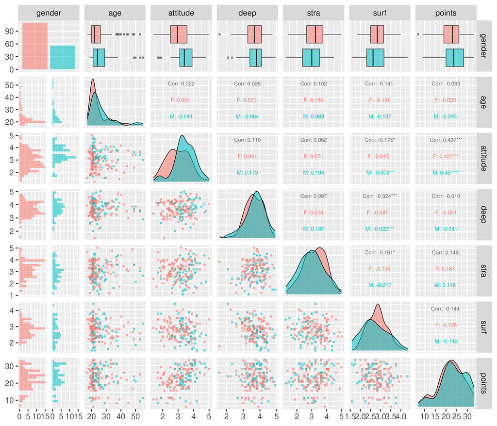

```r
# fig. width and fig.height enlarge the figure below

# Graphical overview
# load libraries
library(ggplot2)
library(GGally)

# create plot matrix
overview_plot <- learning2014 %>%
  ggpairs(mapping = aes(col = gender, alpha = 0.3),
          lower = list(combo = wrap("facethist", bins = 20))) +
  theme_grey(base_size = 20)
overview_plot
```

### 2.2 Regression model

For the multivariable regression model, I selected the three explanatory (predictor) variables *age*, *attitude*, and strategic learning (*stra*). The dependent target variable is **points**. For my model, I set the significance level at p = 0.05.

In my model, *attitude* shows a positive relationship with **points** (p < 0.001). In other words, a positive attitude towards the course led to higher exam results: with an increase of 1 in attitude, the points in the exam are estimated to increase by 3.48 points. On the other hand, *age* and *stra* did not show any significant relationship with the exam results (p > 0.05). There are trends showing that points in the exams very slightly decrease with age but increase using the strategic learning approach, but they are not significant according to my definition. Overall, the explanatory variables I chose in my model only explain 21.8% of the variation in the data, as shown by the multiple R-squared of 0.2182. The fitted model has a residual standard error of 5.26 points.

```r
# Regression model

# create a regression model with three explanatory variables (stra, age, attitude)
lm_model_points_stra_age_attitude <- lm(points ~ stra + age + attitude, data = learning2014)
# show summary of the fitted model
summary(lm_model_points_stra_age_attitude)
```

```
##
## Call:
## lm(formula = points ~ stra + age + attitude, data = learning2014)
##
## Residuals:
##      Min       1Q   Median       3Q      Max
## -18.1149  -3.2003   0.3303   3.4129  10.7599
##
## Coefficients:
##             Estimate Std. Error t value Pr(>|t|)
## (Intercept) 10.89543    2.64834   4.114 6.17e-05 ***
## stra         1.00371    0.53434   1.878   0.0621 .
## age         -0.08822    0.05302  -1.664   0.0981 .
## attitude     3.48077    0.56220   6.191 4.72e-09 ***
## ---
## Signif. codes:  0 '***' 0.001 '**' 0.01 '*' 0.05 '.' 0.1 ' ' 1
##
## Residual standard error: 5.26 on 162 degrees of freedom
## Multiple R-squared:  0.2182, Adjusted R-squared:  0.2037
## F-statistic: 15.07 on 3 and 162 DF,  p-value: 1.07e-08
```

```r
# Does model (R-squared) improve with less explanatory variables?
# create a simple linear regression with attitute
lm_model_points_attitude <- lm(points ~ attitude, data = learning2014)
summary(lm_model_points_attitude) # no
```

```
##
## Call:
## lm(formula = points ~ attitude, data = learning2014)
##
## Residuals:
##      Min       1Q   Median       3Q      Max
## -16.9763  -3.2119   0.4339   4.1534  10.6645
##
## Coefficients:
##             Estimate Std. Error t value Pr(>|t|)
## (Intercept)  11.6372     1.8303   6.358 1.95e-09 ***
## attitude      3.5255     0.5674   6.214 4.12e-09 ***
## ---
## Signif. codes:  0 '***' 0.001 '**' 0.01 '*' 0.05 '.' 0.1 ' ' 1
##
## Residual standard error: 5.32 on 164 degrees of freedom
## Multiple R-squared:  0.1906, Adjusted R-squared:  0.1856
## F-statistic: 38.61 on 1 and 164 DF,  p-value: 4.119e-09
```

```r
# create a regression model with two explanatory variables (stra, attitude)
lm_model_points_stra_attitude <- lm(points ~ stra + attitude, data = learning2014)
summary(lm_model_points_stra_attitude)
```

```
##
## Call:
## lm(formula = points ~ stra + attitude, data = learning2014)
##
## Residuals:
##      Min       1Q   Median       3Q      Max
## -17.6436  -3.3113   0.5575   3.7928  10.9295
##
## Coefficients:
##             Estimate Std. Error t value Pr(>|t|)
## (Intercept)   8.9729     2.3959   3.745  0.00025 ***
## stra          0.9137     0.5345   1.709  0.08927 .
## attitude      3.4658     0.5652   6.132 6.31e-09 ***
## ---
## Signif. codes:  0 '***' 0.001 '**' 0.01 '*' 0.05 '.' 0.1 ' ' 1
##
## Residual standard error: 5.289 on 163 degrees of freedom
## Multiple R-squared:  0.2048, Adjusted R-squared:  0.1951
## F-statistic: 20.99 on 2 and 163 DF,  p-value: 7.734e-09
```

```r
# create a regression model with two explanatory variables (age, attitude)
lm_model_points_age_attitude <- lm(points ~ age + attitude, data = learning2014)
summary(lm_model_points_age_attitude)
```

```
##
## Call:
## lm(formula = points ~ age + attitude, data = learning2014)
##
## Residuals:
##      Min       1Q   Median       3Q      Max
## -17.3354  -3.3095   0.2625   4.0005  10.4911
##
## Coefficients:
##             Estimate Std. Error t value Pr(>|t|)
## (Intercept) 13.57244    2.24943   6.034 1.04e-08 ***
## age         -0.07813    0.05315  -1.470    0.144
## attitude     3.54392    0.56553   6.267 3.17e-09 ***
## ---
## Signif. codes:  0 '***' 0.001 '**' 0.01 '*' 0.05 '.' 0.1 ' ' 1
##
## Residual standard error: 5.301 on 163 degrees of freedom
## Multiple R-squared:  0.2011, Adjusted R-squared:  0.1913
## F-statistic: 20.52 on 2 and 163 DF,  p-value: 1.125e-08
```

### 2.3 Assumptions of the model and validity interpretation

The assumptions for linear regression are as follows: 1. Linearity, *i. e.*, there is a linear relation between the explanatory and target variable. 2. Homoscedasticity, *i. e.*, the variance of the target variable should be the same across the range of the explanatory variable. 3. Normality of the error terms, *i. e.*, the error terms should follow a normal distribution with mean zero.

Because we have continuous variables, we can only assess the assumptions by using and looking at the residuals. The residuals are the difference between the observed and the fitted values. On the top left plot of the following figure (“Residuals vs Fitted”), we can see that the data is relatively normally distributed, so not deviating from the horizontal axis at Y = 0. Also the spread around the horizontal axis at Y = 0 is not deviating too much, so the assumption of homoscedasticity is fulfilled, too. The normality of the error terms can be seen in the top right plot of the following figure (“Normal Q-Q”). There are no major deviations from normality, so this assumption is also fulfilled. In the bottom left plot (“Residuals vs Leverage”), we can get an estimate on how much influence each observation had in the fitting of the regression model due to its explanatory variables.

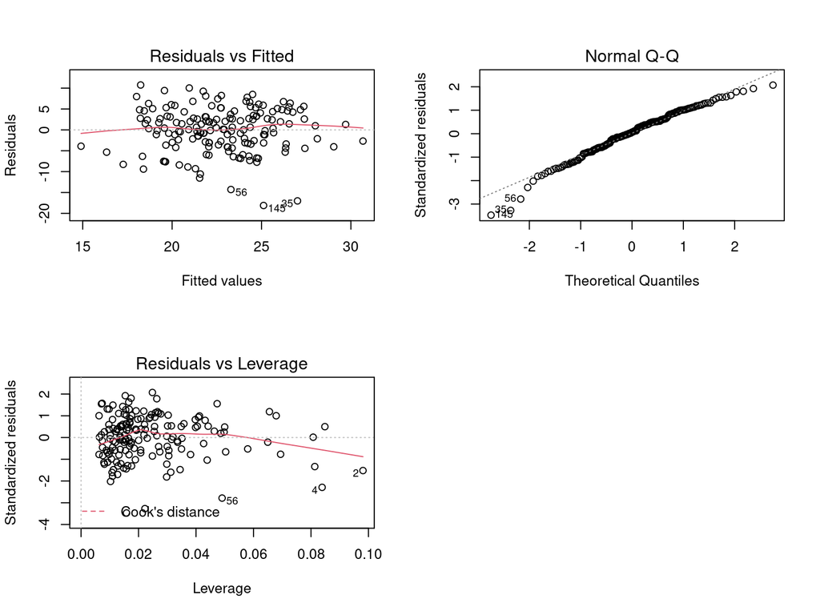

```r
# Plot Residuals vs Fitted values, Normal QQ-plot, and Residuals vs Leverage

par(mfrow = c(2,2))
plot(lm_model_points_stra_age_attitude,
     which = c(1,2,5))
par(mfrow = c(1,1))
```

3. Logistic regression

*This file describes the work and results of the third week a. k. a. “Logistic regression” of the IDOS2023 course.*

3.1 Information on dataset

The original data set includes data from student performances in the subjects “Mathematics” and “Portuguese language” in secondary education (high school) in two Portuguese schools. It was collected through school reports and questionnaires, and gives information on the demographic and social background of the students, as well as student grades and data on the school they visit (click [here](https://archive.ics.uci.edu/dataset/320/student+performance) to see more information on the data set and access the data). One of the collected variables concerns the alcohol consumption of the students.

The data set we use has 370 observations / rows with 35 variables / columns, of which most are numerical integers and binary characters, but also some nominal characters where more than two options are available. It combines the data from two student alcohol consumption data sets, where ‘alc_use’ gives the average of the weekly alcohol consumption from 1 - very low to 5 - very high, and the logical variable ‘high_use’ = TRUE / FALSE indicates if students consume more than a little amount of alcohol (> 2).

```r
# Read and summarise file
# load saved file from data wrangling exercise
alc <- read.table(file='/home/ntriches/github_iods2023/IODS23/data/alc.csv', header=TRUE, sep = ",")
colnames(alc) # names of variables
```

```
##  [1] "school"     "sex"        "age"        "address"    "famsize"
##  [6] "Pstatus"    "Medu"       "Fedu"       "Mjob"       "Fjob"
## [11] "reason"     "guardian"   "traveltime" "studytime"  "schoolsup"
## [16] "famsup"     "activities" "nursery"    "higher"     "internet"
## [21] "romantic"   "famrel"     "freetime"   "goout"      "Dalc"
## [26] "Walc"       "health"     "failures"   "paid"       "absences"
## [31] "G1"         "G2"         "G3"         "alc_use"    "high_use"
```

```r
dim(alc)      # dimension of data
```

```
## [1] 370  35
```

### 3.2 Analysis

#### 3.2.1 Aim

The aim of my analysis is to study the relationships between high / low alcohol consumption and the gender of the students (“sex”, female / male), if they go out with friends often (“goout”, 1 - very low to 5 - very high), if they miss school often (“absences”, number of school absences), and how well they performed in their final grades (“G3”, 0 to 20). My personal hypotheses are as follows:

1. Students identifying as female drink less (relatively) than students identifying as males.
2. If the students go out with friends often, they drink more (= A higher number in *goout* results in high alcohol consumption).
3. The more classes the students miss, the more likely they drink (= The higher the number of school absences, the more likely is a high alcohol consumption.).
4. The more the students drink, the lower their final grade is (= Students showing high consumption of alcohol have lower results in their final grade).

#### 3.2.2 Numerical and graphical exploration

The numerical exploration of our data shows that most students fall under the category of low alcohol consumption (< 2). Females and males are almost equally distributed (195 and 175, respectively). It is evident that in *goout* and *absences*, most students are clustered in the categories 3 and 4 (see medians). It is only with the means that we can see some differences.

```r
library(dplyr)  # load needed library

# summary statistics by group
# differences between female / male and high / low alcohol consumption, mean of going out, mean of absences, mean of final grade
alc %>%
  group_by(sex, high_use) %>%
  summarise(count = n(),
            mean_goout = mean(goout),
            median_goout = median(goout),
            mean_absences = mean(absences),
            median_absences = median(absences),
            mean_grade = mean(G3),
            median_grade = median(G3)
            )
```

```
## # A tibble: 4 × 9
## # Groups:   sex [2]
##   sex   high_use count mean_goout median_goout mean_absences median_absences
##   <chr> <lgl>    <int>      <dbl>        <dbl>         <dbl>           <dbl>
## 1 F     FALSE      154       2.95            3          4.25               3
## 2 F     TRUE        41       3.39            4          6.85               3
## 3 M     FALSE      105       2.70            3          2.91               3
## 4 M     TRUE        70       3.93            4          6.1                4
## # ℹ 2 more variables: mean_grade <dbl>, median_grade <dbl>
```

The clustering of the medians is also evident when looking at the boxplots (see below). In *goout*, the upper quartile equals the median for males in *high use = FALSE*, and in *high use = TRUE* for females. *absences* show a relatively high amount of outliers but generally an increase in *high use = TRUE*. In the grades (*G3*), we can immediately see that there are great differences between females and males.

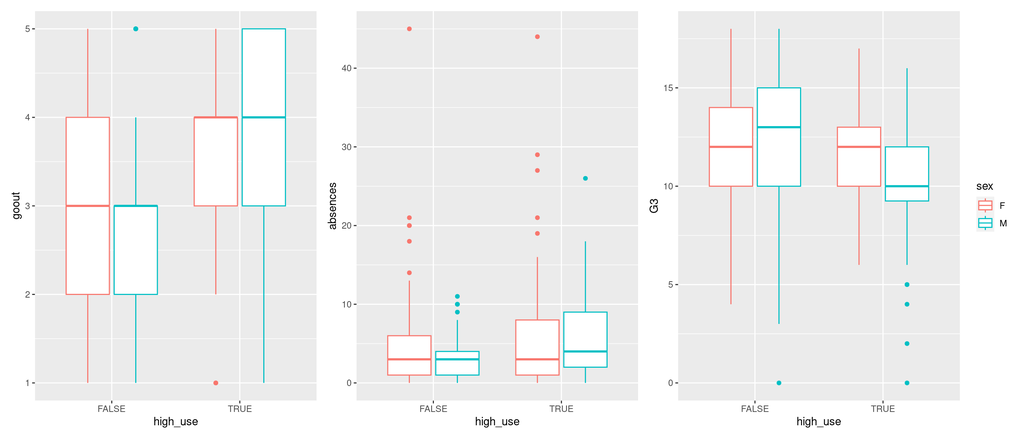

```r
library(dplyr)
library(ggplot2) # load needed libraries
# install.packages("patchwork") to show boxplots next to each other
library(patchwork)

# box plot showing differences between sex concerning high consumption of alcohol and going out
plot_alc_use_goout_by_sex <- alc %>%
  ggplot(aes(x = high_use, y = goout, col = sex)) +
  geom_boxplot()
# box plot showing differences between sex concerning high consumption of alcohol and absences in school
plot_alc_use_absences_by_sex <- alc %>%
  ggplot(aes(x = high_use, y = absences, col = sex)) +
  geom_boxplot()
# box plot showing differences between sex concerning high consumption of alcohol and final grades
plot_alc_use_grades_by_sex <- alc %>%
  ggplot(aes(x = high_use, y = G3, col = sex)) +
  geom_boxplot()
# show and combine all plots
plot_alc_use_goout_by_sex + plot_alc_use_absences_by_sex + plot_alc_use_grades_by_sex + plot_layout(guides = 'collect')
```

Concerning my hypotheses, this means the following:

1. 40% of males show a high alcohol consumption (70 TRUE / 175 total * 100). Compared to 21 % of the females showing a high alcohol consumption (41 TRUE / 195 total * 100), I can assume that my first hypothesis, males drinking more than females, can be accepted.
2. Females who have a high alcohol consumption go out more often (3.4) compared to those who go out less frequently (3). For males, the differences is even greater: those going out often (3.9) drink more compared to those who go out less (2.7). I can therefore assume that my seconds hypothesis, that those students who go out often drink more, can be accepted.
3. Females seem to miss school more often than males but for both genders, the same trend is evident: they show a high use of alcohol with a higher number of absences. I can assume that my third hypothesis can be accepted.
4. Males who show a high alcohol consumption achieve lower grades in their final exam compared to those with low alcohol consumption (10.3 and 12.3, respectively). For females, the differences in the final grades are smaller and show an opposite trend: with high alcohol consumption, the final grades are slightly higher than with low alcohol consumption (11.8 and 11.4, respectively). My fourth hypothesis, that high alcohol consumption results in lower final grades, can therefore only be accepted partially.

#### 3.2.3 Logistic regression model

We use a logistic regression to statistically explore the relationship between the binary high / low alcohol consumption variable as the target variable, and the explanatory variables gender (*sex*), how often students go out (*goout*), their absences at school (*absences*), and their final grades (*G3*).

```r
# find the model with glm()
model_high_use_sex_goout_absences_grades <- glm(high_use ~ sex + goout + absences + G3, data = alc, family = "binomial")

# print out a summary of the model
summary(model_high_use_sex_goout_absences_grades) # G3 (grades) not statistically significant
```

```
##
## Call:
## glm(formula = high_use ~ sex + goout + absences + G3, family = "binomial",
##     data = alc)
##
## Deviance Residuals:
##     Min       1Q   Median       3Q      Max
## -1.9500  -0.7990  -0.5263   0.8110   2.4703
##
## Coefficients:
##             Estimate Std. Error z value Pr(>|z|)
## (Intercept) -3.58037    0.70357  -5.089 3.60e-07 ***
## sexM         1.01859    0.25986   3.920 8.87e-05 ***
## goout        0.70551    0.12167   5.799 6.68e-09 ***
## absences     0.08263    0.02267   3.645 0.000268 ***
## G3          -0.04508    0.03985  -1.131 0.258029
## ---
## Signif. codes:  0 '***' 0.001 '**' 0.01 '*' 0.05 '.' 0.1 ' ' 1
##
## (Dispersion parameter for binomial family taken to be 1)
##
##     Null deviance: 452.04  on 369  degrees of freedom
## Residual deviance: 372.82  on 365  degrees of freedom
## AIC: 382.82
##
## Number of Fisher Scoring iterations: 4
```

We can see that *absences*, *goout*, and *sexM* show very significant positive correlations with a high alcohol consumption (p < 0.001), whereas the final grades (*G3*) do not show a significant relationship with alcohol consumption. *sexM* indicates that males are more likely to drink a lot of alcohol compared to females. In other words, male students, students who miss a lot of classes, and students who go out more often drink more alcohol.

```r
# compute odds ratios (OR)
OR <- coef(model_high_use_sex_goout_absences_grades) %>%
  exp

# compute confidence intervals (CI)
CI <- confint(model_high_use_sex_goout_absences_grades) %>%
  exp

# print out the odds ratios with their confidence intervals
cbind(OR, CI)
```

```
##                     OR       2.5 %    97.5 %
## (Intercept) 0.02786536 0.006654554 0.1057209
## sexM        2.76927745 1.674593890 4.6488214
## goout       2.02488717 1.604625853 2.5882364
## absences    1.08614409 1.040269147 1.1384190
## G3          0.95592337 0.883818334 1.0338017
```

The odds ratios show that the odds that males have a high alcohol consumption are 2.8 with a 95 % confidence interval ranging from 1.7 to 4.6. Similarly, the odds of students going out more having a high alcohol consumption are 2 with a confidence interval ranging between 1.6 and 2.6.

#### 3.2.4 Predictions

With our logistic regression model, it is possible to make predictions, and explore how well the models actually predicts the target variable *high alcohol consumption*. We can do this proving a 2x2 cross tabulation of predictions versus the actual values, and a graphic visualisation of predictions and actual values (see below). To improve our model, we remove the explanatory variable that didn’t have a significant relationship with the alcohol consumption (*G3*).

```r
# run new model without grades (G3) because they had no significant influence on high_use
model_high_use_sex_goout_absences <- glm(high_use ~ sex + goout + absences, data = alc, family = "binomial")
# print out summary of model
summary(model_high_use_sex_goout_absences)
```

```
##
## Call:
## glm(formula = high_use ~ sex + goout + absences, family = "binomial",
##     data = alc)
##
## Deviance Residuals:
##     Min       1Q   Median       3Q      Max
## -1.8060  -0.8090  -0.5248   0.8214   2.4806
##
## Coefficients:
##             Estimate Std. Error z value Pr(>|z|)
## (Intercept) -4.18142    0.48085  -8.696  < 2e-16 ***
## sexM         1.02223    0.25946   3.940 8.15e-05 ***
## goout        0.72793    0.12057   6.038 1.56e-09 ***
## absences     0.08478    0.02266   3.741 0.000183 ***
## ---
## Signif. codes:  0 '***' 0.001 '**' 0.01 '*' 0.05 '.' 0.1 ' ' 1
##
## (Dispersion parameter for binomial family taken to be 1)
##
##     Null deviance: 452.04  on 369  degrees of freedom
## Residual deviance: 374.10  on 366  degrees of freedom
## AIC: 382.1
##
## Number of Fisher Scoring iterations: 4
```

```r
# predict() the probability of high_use and add to alc data frame
alc <- mutate(alc, probability = predict(model_high_use_sex_goout_absences, type = "response"))
# use the probabilities to make a prediction of high_use
alc <- mutate(alc, prediction = probability > 0.5)
# tabulate the target variable versus the predictions: 2x2 cross tabulation
table(high_use = alc$high_use, prediction = alc$prediction) %>%
  addmargins()
```

```
##         prediction
## high_use FALSE TRUE Sum
##    FALSE   242   17 259
##    TRUE     61   50 111
##    Sum     303   67 370
```

```r
# tabulate the target variable versus the predictions in percentages
table(high_use = alc$high_use, prediction = alc$prediction) %>%
  prop.table() %>%
  addmargins()
```

```
##         prediction
## high_use      FALSE       TRUE        Sum
##    FALSE 0.65405405 0.04594595 0.70000000
##    TRUE  0.16486486 0.13513514 0.30000000
##    Sum   0.81891892 0.18108108 1.00000000
```

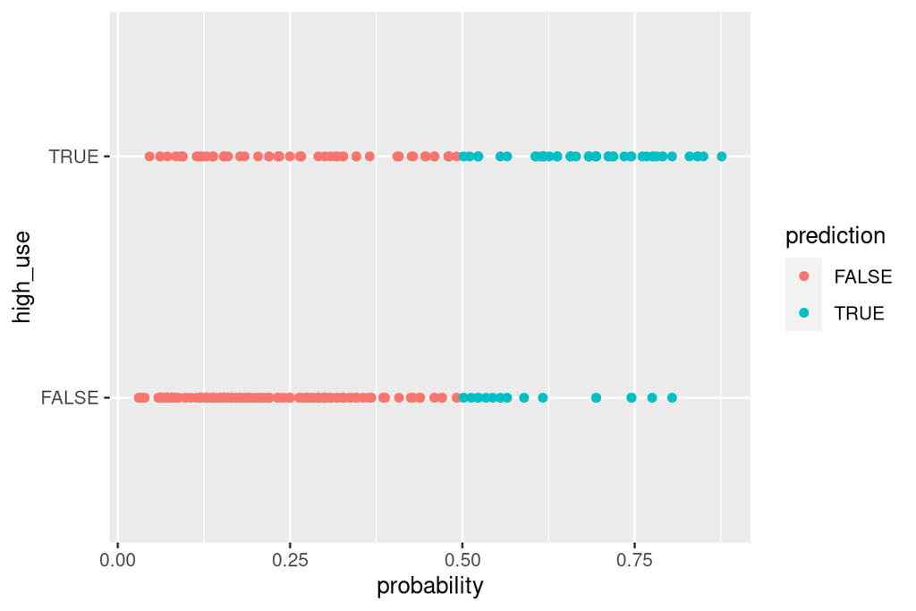

```r
# plot 'high_use' versus 'probability'
plot_probability_high_use_prediction <- alc %>%
  ggplot(aes(x = probability, y = high_use, col = prediction)) +
  geom_point()
plot_probability_high_use_prediction
```

```r
# define a loss function (mean prediction error)
loss_func <- function(class, prob) {
  n_wrong <- abs(class - prob) > 0.5
  mean(n_wrong)
}

# call loss_func to compute the average number of wrong predictions in the (training) data
loss_func(class = alc$high_use, prob = 0)
```

```
## [1] 0.3
```

```r
# call loss_func to compute the average number of right predictions in the (training) data
loss_func(class = alc$high_use, prob = 1)
```

```
## [1] 0.7
```

#### 3.2.5 Cross-validation

Cross-validation is a method which we can use to get a good estimate of the actual predictive power and the model. We can also use it to compre different models. As we can see below, my model shows an error of 0.21 with a 10-fold cross-validation. This is lower than the model in the Exercise set (error = 0.26).

```r
library(boot)

# 10-fold cross-validation
ten_fold_cross_validation <- cv.glm(data = alc, cost = loss_func, glmfit = model_high_use_sex_goout_absences, K = 10)
# average number of wrong predictions in the cross validation
ten_fold_cross_validation$delta[1]
```

```
## [1] 0.2081081
```

# 4. Clustering and classification

*This file describes the work and results of the fourth week a. k. a. “Clustering and classification” of the IDOS2023 course.*

[^1]: Doctoral Programme in Atmospheric Sciences at the University of Helsinki.